# 2. Example code for running coralseed

2023-09-11

### 1. Load packages and set seascape_probability

First step is to generate a probabilistic habitat map for settlement. The `seascape_probability` function takes two shp files as inputs: 1) a map of reef substrates (merged classes of “coral/algae”, “rubble”, “rock” from the Allan Coral Atlas Benthic classes), and 2) a map of benthic habitat (e.g. “reef crest”, “reef slope” etc classes from geomorphic Allan Coral Atlas maps). The function generates a probability mosaic for settleable area (reef substrates) categorised by habitat types. Example `reef_outline` and `habitat` files are included for Lizard Island. To change the probabilities see `?settlement_probability`.

```r
devtools::load_all("/Users/rof011/coralseed")
#library(coralseed)
library(ggplot2)
library(tidyverse)
library(sf)

library(widgetframe)
library(htmlwidgets)
library(tmap)


seascape <- seascape_probability(reefoutline=reef_map, habitat=benthic_map)
```

### 2. Seed particles based on dispersal input

`seed_particles` outputs summary statistics (set `silent=FALSE`) and summary plots of the main outputs (competency, mortality, spatial pattern (cartesian) and dispersaltime - set `return.plot=TRUE` to visualise these). Try changing the parameters and visualising the output.

The function returns an `sf` output in with spatial points for each individual particle (`id`) at 1 minute timesteps (`dispersaltime`) across trajectories and details the time in minutes when each particle becomes competent (`settlement_point`), the particle `state` (either 0 or 1) and `competency` (incompetent or competent), the benthic habitat it crosses at that point in time (`class`), unique habitat identifier (`habitat_id`) and `settlement_probability` for each habitat determined from the previous step, the `settlement_outcome` (i.e. was the particle competent AND probable to settle?), and finally the `outcome` (i.e. the transition between 0 and 1 is the final settlement point for a given particle).

```
##
## Importing 1000 particle tracks
## [No seed set, random draws used]
##
## Time start = 2022-12-17 04:00:00
## Time end = 2022-12-17 16:57:00
## Total dispersaltime (hrs) = 12.95
##
## Competency at t6 = 164 / 1000 larvae
## Competency at t12 = 296 / 1000 larvae
## Competency at t24 = 480 / 1000 larvae
##
## Survivorship curve typeI
## Mortality at t6 = 7 / 1000 larvae
## Mortality at t12 = 22 / 1000 larvae
```

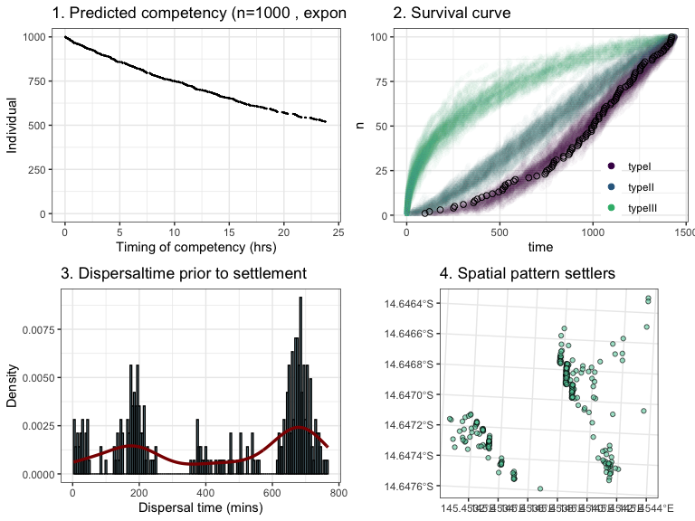

```r
particles <- seed_particles(input="example-mermaid", seascape=seascape,
                            competency.function = "exponential",
                            limit_time=6, simulate.mortality = "typeI",
                            simulate.mortality.n = 0.1, probability="additive",
                            return.plot=TRUE)
```

### 3. Settle particles based on benthic habitats and probability

The `settle_particles` function takes the input from `seed_particles` and determines where along the settlement track each particle settles. As there’s currently no data on how larvae settle and interact in the wild, the function adds three different possibilities: “additive” (if p=1 AND larvae are competent, larvae settle somewhere in that habitat along the particle trajectory), “lagged” (if p=1 AND larvae are competent, larvae settle somewhere in the habitat in the first 10 minutes, and “rapid” (if p=1 AND larvae are competent, larvae settle immediately once entering the habitat.

All larvae that are competent will settle somewhere in a habitat if p=1. “rapid” will produce unrealistic results as larvae will immediately settle on the borders of habitats. “lagged” is probably more realistic, but given that habitats are relatively small in size (seascapes are spatially complex) and most larvae pass through habitats fairly rapidly, either “lagged” or “additive” will produce fairly realistic results.

```r
settlers <-  settle_particles(particles, probability="additive", silent=TRUE)
```

### 4. Map the output

To spatially map all the above outputs, use the `map_coralseed` function. `map_coralseed` takes the outputs from steps 1 (`seascape_probability`), step 2 (`seed_particles`), and step 3 (`settle_particles`) as inputs and uses the `tmap` library to plot the shp files, particle tracks, and settlement points. The `restoration.plot` function takes a vector of width and length and draws a rectangular area over the centroid of the particle release.

[interactive chart not shown]